# Overview

# All Command Options

## SPEAQeasy Options

### Mandatory Parameters

- `--reference` “hg38”, “hg19”, “mm10”, or “rn6”: the reference genome to which reads are aligned
- `--sample` “single” or “paired”: the orientation of your reads
- `--strand` “unstranded”, “forward”, or “reverse”: the strandness of your reads. Since strandness is inferred by sample in the pipeline, this option informs the pipeline to generate appropriate warnings if unexpected strandness is inferred.

## Nextflow Options

The nextflow command itself provides many additional options you may add to your “main” script. A few of the most commonly applicable ones are documented below. For a full list, type `[path to nextflow] run -h`- the full list does not appear to be documented at [nextflow’s website](https://www.nextflow.io/).

- `-w [path]` Path to the directory where nextflow will place temporary files. This directory can fill up very quickly, especially for large experiments, and so it can be useful to set this to a scratch directory or filesystem with plenty of storage capacity.
- `-resume` Include this flag if pipeline execution halts with an error for any reason, and you wish to continue where you left off from last run. Otherwise, **by default, nextflow will restart execution from the beginning**.
- `-with-report [filename]` Include this to produce an html report with execution details (such as memory usage, completion details, and much more)
- `N [email address]` Sends email to the specified address to notify the user regarding pipeline completion. Note that nextflow relies on the `sendmail` tool for this functionality- therefore `sendmail` must be available for this option to work.

# Pipeline Overview

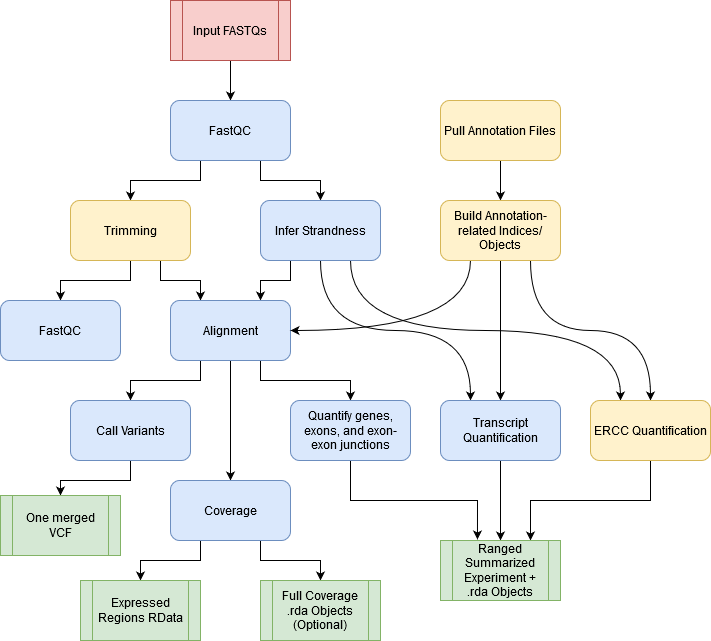

Functional workflow